# Regression Diagnostics

An excellent review of regression diagnostics is provided in *Overview of Regression Diagnostics*.

Dr. John Fox's {car} package provides advanced utilities for regression modeling. The prestige data set comes with the car package

#### `avPlots`

- Graphs outcome vs predictor variables holding the rest constant (also called partial-regression plots)
- Help identify the effect(or influence) of an observation on the regression coefficient of the predictor variable

# Regression Diagnostics

```r
library(car)
```

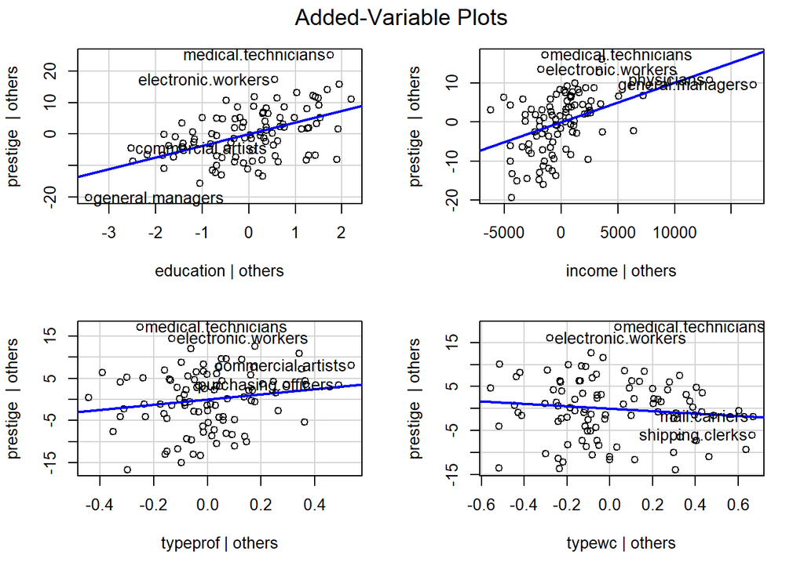

```r
reg1 <-lm(prestige ~ education + income + type, data = Prestige)
avPlots(reg1)
```

#### `influenceIndexPlot`

- Cook's distance measures how much an observation influences the overall model or predicted values
- Studentizided residuals are the residuals divided by their estimated standard deviation as a way to standardized
- Bonferronitest to identify outliers
- Hat-points identify influential observations (have a high impact on the predictor variables)

# Regression Diagnostics

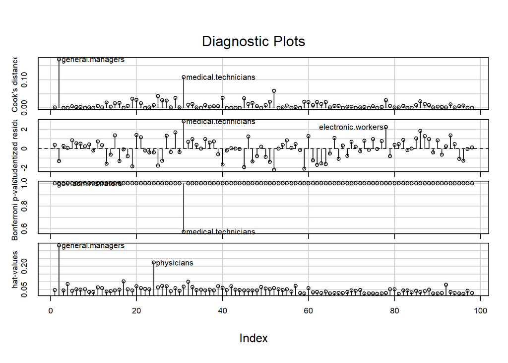

```r
library(car)
reg1 <-lm(prestige ~ education + income + type, data = Prestige)
influenceIndexPlot(reg1)
```

#### `influencePlot`

- `influencePlot()` creates a bubble-plot combining the display of Studentizedresiduals, hat-values, and Cook's distance (represented in the circles).

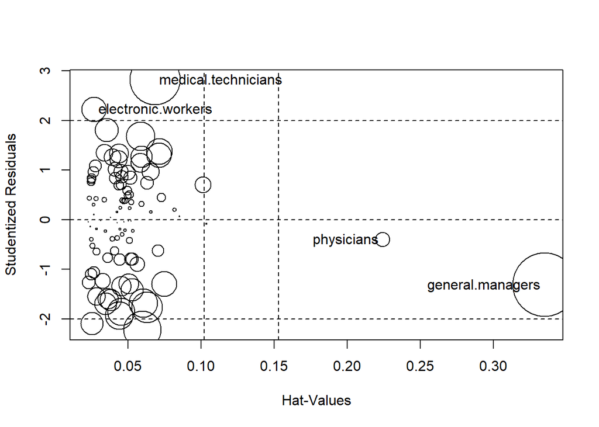

```
##                        StudRes        Hat       CookD
## general.managers    -1.3134574 0.33504477 0.172503975
## physicians          -0.3953204 0.22420309 0.009115491
## medical.technicians  2.8210910 0.06858836 0.109052582
## electronic.workers   2.2251940 0.02701237 0.026372394
```

```r
library(car)
reg1 <-lm(prestige ~ education + income + type, data = Prestige)
influencePlot(reg1)
```

# Alcohol and Tobacco Data

This example is for exposition only. We will ignore the fact that this may not be a great way of modeling the this particular set of data!

```r
alctob <- data.frame( cbind(
Alcohol = c(6.47, 6.13, 6.19, 4.89, 5.63, 4.52,
            5.89, 4.79, 5.27, 6.08, 4.02),
Tobacco = c(4.03, 3.76, 3.77, 3.34, 3.47, 2.92,
            3.20, 2.71, 3.53, 4.51, 4.56)),
row.names = c("North", "Yorkshire", "Northeast",
"East Midlands", "West Midlands", "East Anglia",
"Southeast", "Southwest", "Wales",
"Scotland", "N. Ireland"))
```

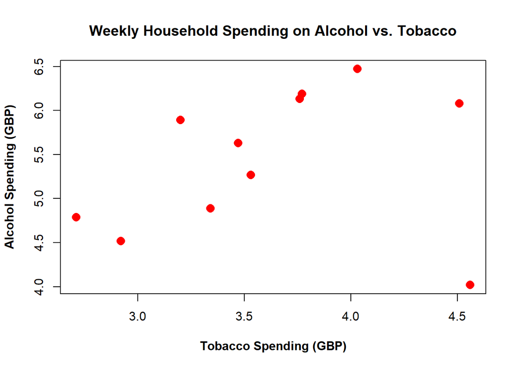

```r
alctobwo <- subset(alctob,rownames(alctob)!="N. Ireland")
#without North Ireland

plot(alctob$Tobacco, alctob$Alcohol,
main="Weekly Household Spending on Alcohol vs. Tobacco",
xlab="Tobacco Spending (GBP)",
ylab="Alcohol Spending (GBP)",
pch=16,col="red",cex=1.5,font.lab=2)
```

```r
#note N. Ireland in the bottom-right
```

```r
fit1 <- lm( Alcohol ~ Tobacco, data = alctob)
fit2 <- lm( Alcohol ~ Tobacco, data = alctobwo)
```

# All Observations

```r
summary(fit1)
```

```
##
## Call:
## lm(formula = Alcohol ~ Tobacco, data = alctob)
##
## Residuals:
##     Min      1Q  Median      3Q     Max
## -1.7080 -0.4245  0.2311  0.6081  0.9020
##
## Coefficients:
##             Estimate Std. Error t value Pr(>|t|)
## (Intercept)   4.3512     1.6067   2.708   0.0241 *
## Tobacco       0.3019     0.4388   0.688   0.5087
## ---
## Signif. codes:  0 '***' 0.001 '**' 0.01 '*' 0.05 '.' 0.1 ' ' 1
##
## Residual standard error: 0.8196 on 9 degrees of freedom
## Multiple R-squared:  0.04998,    Adjusted R-squared:  -0.05557
## F-statistic: 0.4735 on 1 and 9 DF,  p-value: 0.5087
```

# Outlier Removed

```r
summary(fit2)
```

```
##
## Call:
## lm(formula = Alcohol ~ Tobacco, data = alctobwo)
##
## Residuals:
##      Min       1Q   Median       3Q      Max
## -0.51092 -0.42434  0.06056  0.34406  0.62991
##
## Coefficients:
##             Estimate Std. Error t value Pr(>|t|)
## (Intercept)   2.0412     1.0014   2.038  0.07586 .
## Tobacco       1.0059     0.2813   3.576  0.00723 **
## ---
## Signif. codes:  0 '***' 0.001 '**' 0.01 '*' 0.05 '.' 0.1 ' ' 1
##
## Residual standard error: 0.446 on 8 degrees of freedom
## Multiple R-squared:  0.6151, Adjusted R-squared:  0.567
## F-statistic: 12.78 on 1 and 8 DF,  p-value: 0.007234
```

# Outliers

The conservative outlier test that we talked about in class uses the Bonferonni inequality to calculate the p-values we associate with the Student's-t test.

In R, we can use the `outlierTest()`` command to perform this test on our model. Remember that when we test for influence, we are testing the effect of an observation on model coefficients.

Therefore we need to give the outlierTest command a linear model as its input.

```r
outlierTest(fit1)
```

```
##             rstudent unadjusted p-value Bonferroni p
## N. Ireland -4.732091          0.0014789     0.016268
```

We can also use R to calculate Cook's distance. Here we label any observation with Cook's distance greater than 1 as influential.

```r
cooks.distance(fit1)
```

```
##         North     Yorkshire     Northeast East Midlands West Midlands
##   0.114101051   0.036517838   0.043728951   0.023600304   0.004740759
##   East Anglia     Southeast     Southwest         Wales      Scotland
##   0.147326647   0.046646563   0.077488350   0.001821694   0.068921892
##    N. Ireland
##   1.747233521
```

Finally, one of the easier ways to evaluate our residuals and look for for influential points is through plots.

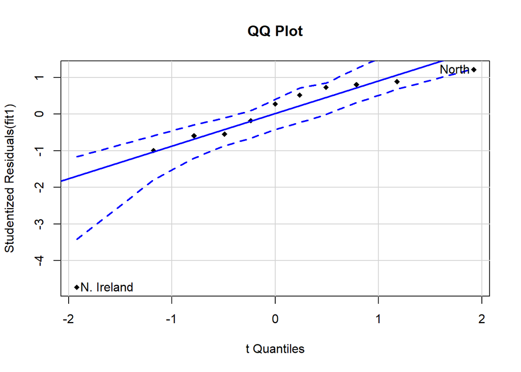

```
##      North N. Ireland
##          1         11
```

```r
#qq plot for studentized resid
qqPlot(fit1, main="QQ Plot",pch=18, lim=c(-3,2))
```

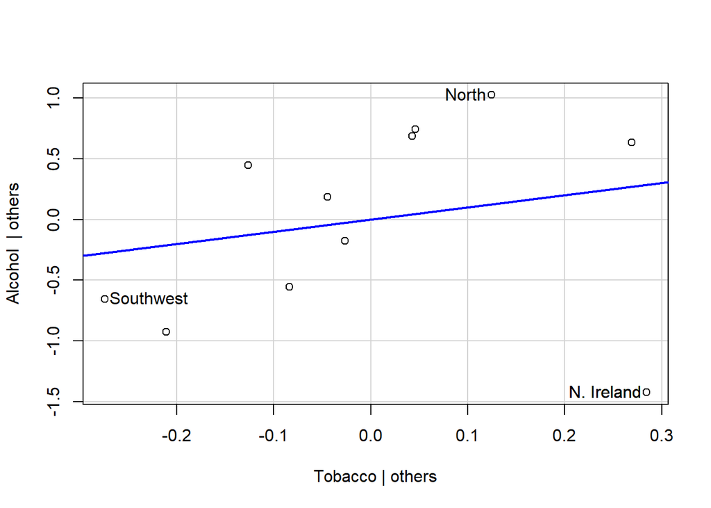

```r
# leverage plots
leveragePlots(fit1)
```

```r
fit <- fit1
```

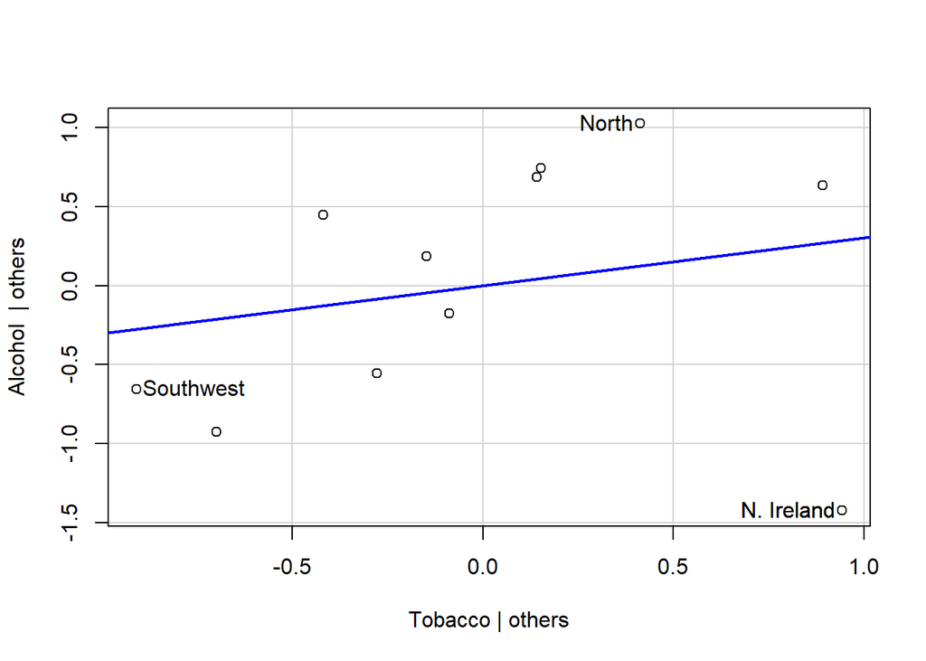

```r
# Influential Observations
# Influential Observations
# added variable plots
avPlots(fit1)
```

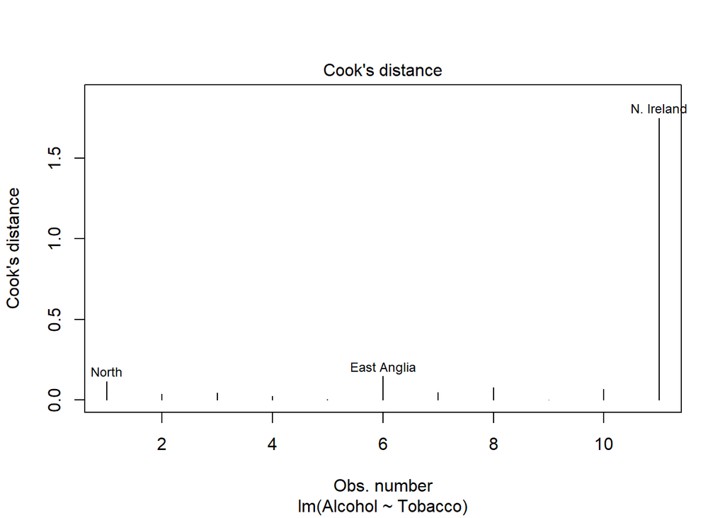

```r
# Cook's D plot
# identify D values > 4/(n-k-1)
cutoff <- 4/((nrow(mtcars)-length(fit1$coefficients)-2))
plot(fit, which=4, cook.levels=cutoff)
```

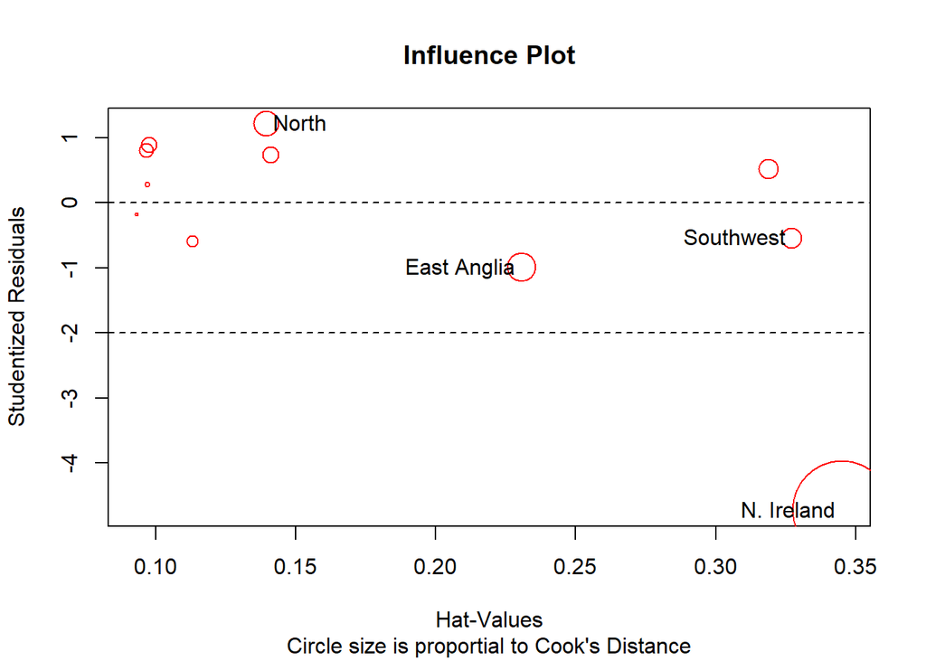

```
##                StudRes       Hat      CookD
## North        1.2178081 0.1395123 0.11410105
## East Anglia -0.9904538 0.2306073 0.14732665
## Southwest   -0.5417970 0.3272829 0.07748835
## N. Ireland  -4.7320908 0.3451163 1.74723352
```

```r
# Influence Plot
influencePlot(fit1,id.method="identify",
main="Influence Plot",
col="red",
sub="Circle size is proportial to Cook's Distance" )
```

# Non-normality

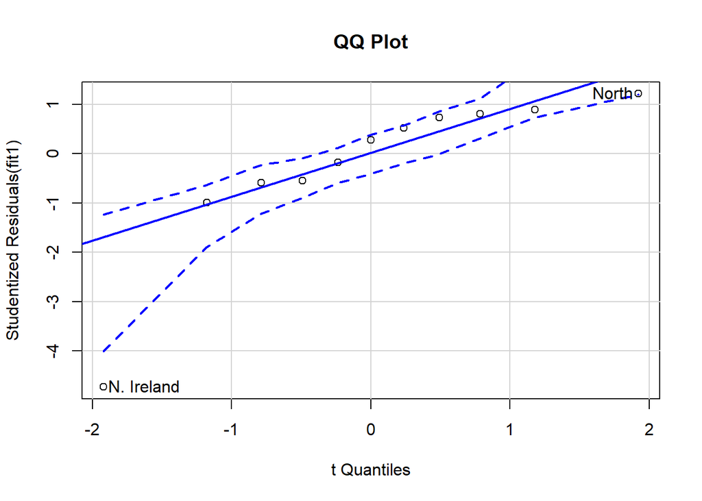

```
##      North N. Ireland
##          1         11
```

```r
# Normality of Residuals
# qq plot for studentized resid
qqPlot(fit1, main="QQ Plot")
```

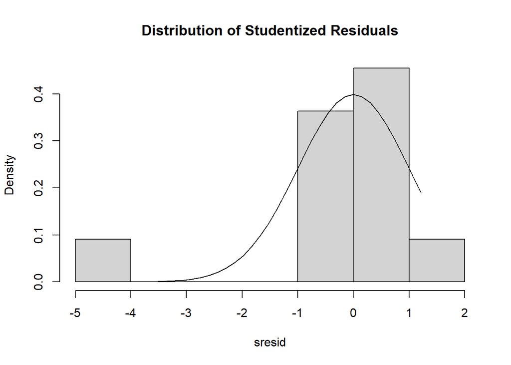

```r
# distribution of studentized residuals
library(MASS)
sresid <- studres(fit)
hist(sresid, freq=FALSE,
main="Distribution of Studentized Residuals")
xfit<-seq(min(sresid),max(sresid),length=40)
yfit<-dnorm(xfit)
lines(xfit, yfit)
```

# Non-constant Error Variance

```r
# Evaluate homoscedasticity
# non-constant error variance test
ncvTest(fit)
```

```
## Non-constant Variance Score Test
## Variance formula: ~ fitted.values
## Chisquare = 3.311276, Df = 1, p = 0.068806
```

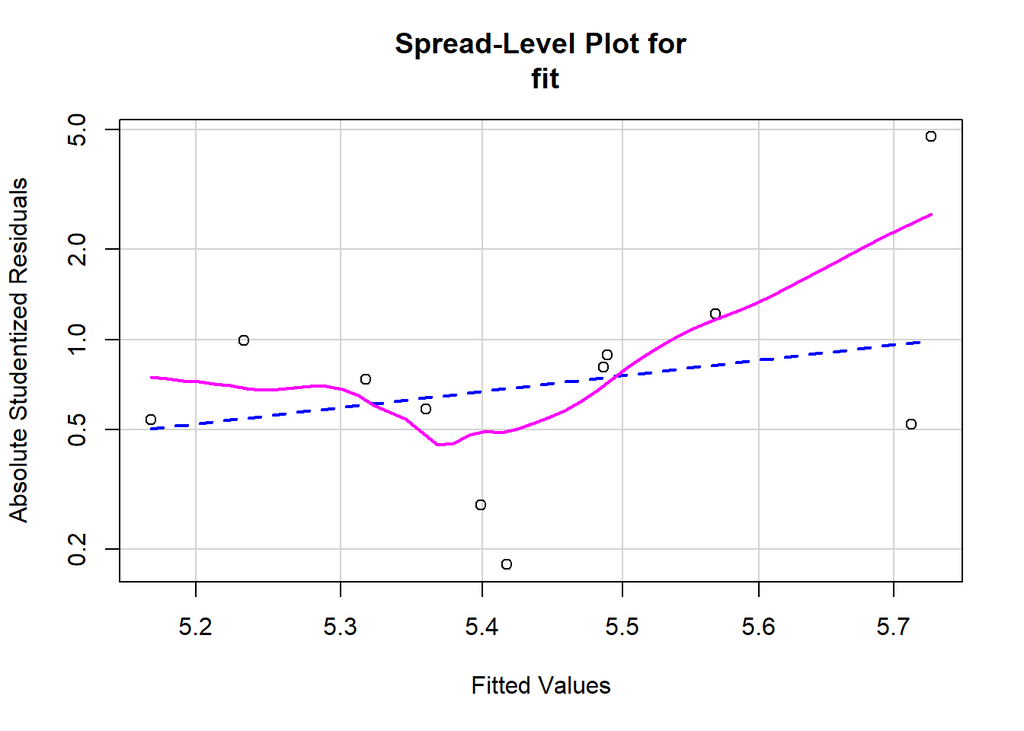

```
##
## Suggested power transformation:  -5.624329
```

```r
# plot studentized residuals vs. fitted values
spreadLevelPlot(fit)
```